# (2/3) Sigmoidal model

Umut Caglar

2017-03-27

# The Sigmoidal Fit Function This is a document invetigates details of sigmoidal model

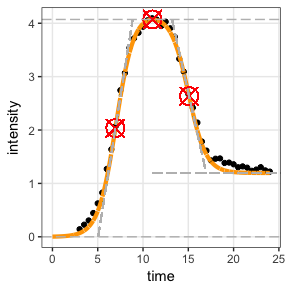

## Data generation

To simulate the results, we will go backwards and firstly generate some data to analize. To add some randomness to the input data I will use some noise. The input of all package must be in the form of a data frame with at least 2 columns time and intensity.

`sicegar::sigmoidalFitFormula` generate a set of intensity values based on maximum, slope parameter and midPoint values supplied. So here we are generating a set of points that are on a sigmoidal with a */slope parameter/* of 1, maximum of 4 and midpoint of 8.

The sigmoidal fit formula uses the function  
`y = (0 + (maximum - 0) / (1 + exp((-slopeParam)*(x - midPoint))))`  
and if we calculate the derivative of it at the midpoint we find the slope as  
`max_slope = 1/4 * slopeParam * maximum`  
**i.e what we provide to `sicegar::sigmoidalFitFormula` as slope parameter is not the maximum slope but a parameter related with maximum slope**.

```r
time=seq(3,24,0.5)

#simulate intensity data and add noise
noise_parameter=0.1
intensity_noise=stats::runif(n = length(time),min = 0,max = 1)*noise_parameter
intensity=sigmoidalFitFormula(time, maximum = 4, slopeParam = 1, midPoint = 8)
intensity=intensity+intensity_noise

dataInput=data.frame(intensity=intensity,time=time)
```

## Data normalization

This is the first step. Data should be normalized before any fit. I.e time and intensity should be in between 0-1 interval.

There is a nuance

- Time is normalized with respect to maximum value the time parameter takes.

```r
timeRatio=max(timeData); timeData=timeData/timeRatio
```

- Intensity is normalized with respect to intensity interval

```r
intensityMin = min(dataInput$intensity)
intensityMax = max(dataInput$intensity)
intensityRatio = intensityMax - intensityMin

intensityData=dataInput$intensity-intensityMin
intensityData=intensityData/intensityRatio
```

The normalization code is

```r
normalizedInput = sicegar::normalizeData(dataInput = dataInput,
                                         dataInputName = "Sample001")
```

Components of the normalization output

```r
head(normalizedInput$timeIntensityData) # the normalized time and intensity data
```

```
##        time   intensity
## 1 0.1250000 0.000000000
## 2 0.1458333 0.002079141
## 3 0.1666667 0.002811145
## 4 0.1875000 0.004563081
## 5 0.2083333 0.026984704
## 6 0.2291667 0.052748267
```

```r
print(normalizedInput$dataScalingParameters) # the normalization parameters that is needed to go back to original scale
```

```
##      timeRatio   intensityMin   intensityMax intensityRatio
##     24.0000000      0.1065867      4.0969597      3.9903731
```

```r
print(normalizedInput$dataInputName) # a useful feature to track the sample in all the process
```

```
## [1] "Sample001"
```

## The figures of raw and normalized datasets

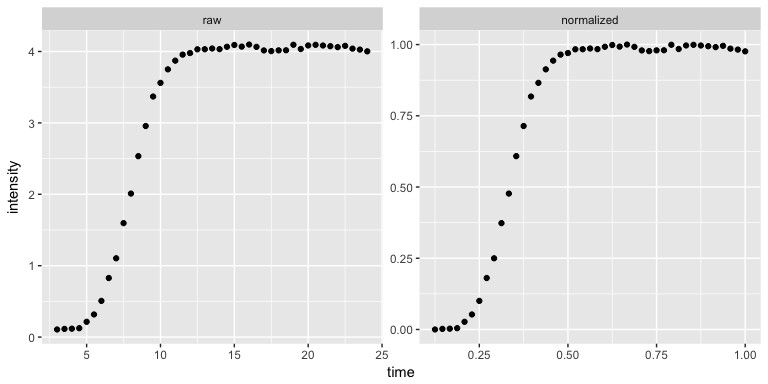

## Sigmoidal fit of the data

Now it is time to calculate the parameters by using `sicegar::sigmoidalFitFunction()`

```r
parameterVector<-sicegar::sigmoidalFitFunction(normalizedInput,tryCounter=2)

# Where tryCounter is a tool usually provided by sicegar::fitFunction when the sicegar::sigmoidalFitFunction is called from sicegar::fitFunction.

# If tryCounter==1 it took the  start position given by sicegar::fitFunction
# If tryCounter!=1 it generates a random start position from given interval
```

the function outputs a vector that gives information about multiple parameters

```r
print(t(parameterVector))
```

```
##                                      [,1]
## maximum_N_Estimate                   "0.9892762"
## maximum_Std_Error                    "0.00172638"
## maximum_t_value                      "573.035"
## maximum_Pr_t                         "6.473165e-80"
## slopeParam_N_Estimate                "24.91311"
## slopeParam_Std_Error                 "0.3550745"
## slopeParam_t_value                   "70.16306"
## slopeParam_Pr_t                      "1.684373e-43"
## midPoint_N_Estimate                  "0.3352606"
## midPoint_Std_Error                   "0.0006568671"
## midPoint_t_value                     "510.3933"
## midPoint_Pr_t                        "6.635815e-78"
## residual_Sum_of_Squares              "0.003021868"
## log_likelihood                       "144.5919"
## AIC_value                            "-281.1837"
## BIC_value                            "-274.1389"
## isThisaFit                           "TRUE"
## startVector.maximum                  "0.702167"
## startVector.slopeParam               "94.52226"
## startVector.midPoint                 "0.3882737"
## dataScalingParameters.timeRatio      "24"
## dataScalingParameters.intensityMin   "0.1065867"
## dataScalingParameters.intensityMax   "4.09696"
## dataScalingParameters.intensityRatio "3.990373"
## model                                "sigmoidal"
## additionalParameters                 "FALSE"
## maximum_Estimate                     "4.054168"
## slopeParam_Estimate                  "1.038046"
## midPoint_Estimate                    "8.046254"
```

Here is the brief explanations of the parameters that are given by `sicegar::sigmoidalFitFunction` (In different order then than the output vector of the sigmoidalFitFunction)

These are the parameters of the normalization step

- `dataScalingParameters.timeRatio`: Maximum of raw time data
- `dataScalingParameters.intensityMin`: Minimum of raw intensity data
- `dataScalingParameters.intensityMax`: Maximum of raw intensity data
- `dataScalingParameters.intensityRatio`: Maximum - Minimum of intensity data

They are the meta summary of the result parameters

- `model`: Gives the used model for fitting
- `additionalParameters`: Wheather the additional parameters are calculated or not. The additional parameters are the meaningful parameters for external usage. They can be calculated with the help of `sicegar::parameterCalculation` function.
- `isThisaFit`: FALSE means there is not any successful fit. TRUE means there is at least one successful fit

Likelihood maximization algorithm starts from a random initiation (if tryCounter!=1) point and goes down the fitness space by a gradient decent algorithm. these parameters represent the start point of the gradient decent algorithm.

- `startVector.maximum`: Maximum value of the initiation point
- `startVector.slopeParam`: Slope Parameter value of the initiation point
- `startVector.midPoint`: Mid-point value of the initiation point

For each parameter that needs to fitted by LM algorithm; the algorithm gives a bunch of statistical parameters; including the estimated value of the parameter

They are the parameters associated with parameter “maximum”

- `maximum_N_Estimate`: Here N stand for the intersection in the normalized scale
- `maximum_Std_Error`
- `maximum_t_value`
- `maximum_Pr_t`

They are the parameters associated with parameter “slope”

- `slopeParam_N_Estimate`: Here N stand for the intersection in the normalized scale. It is not slope it is a parameter related with slope
- `slopeParam_Std_Error`
- `slopeParam_t_value`
- `slopeParam_Pr_t`

They are the parameters associated with parameter “midpoint”

- `midPoint_N_Estimate`: Here N stand for the intersection in the normalized scale
- `midPoint_Std_Error`
- `midPoint_t_value`
- `midPoint_Pr_t`

They are the parameters associated with the quality of the fit.

- `residual_Sum_of_Squares`: Small value indicate better fit
- `log_likelihood`: Higher value indicate a better fit
- `AIC_value`: Smaller value indicate a better fit
- `BIC_value`: Smaller value indicate a better fit

They are the fitted values after converting everything from normalized to un-normalized scale.

- `maximum_Estimate`Maximum intensity estimate for the raw data
- `slopeParam_Estimate`: **Slope parameter** estimate for the raw data
- `midPoint_Estimate`: Mid-point estimate (time the intensity reaches 1/2 of maximum) for the raw data

## Check the results to see if the results are meaningfull

By using the `maximum_Estimate`, `slopeParam_Estimate`, `midPoint_Estimate` parameters of the sigmoidalfit and the time sequence that we already created we can calculate the intensity values by the help of `sicegar::sigmoidalFitFormula()`. We can draw the best sigmoidal fit on top of our initial data.

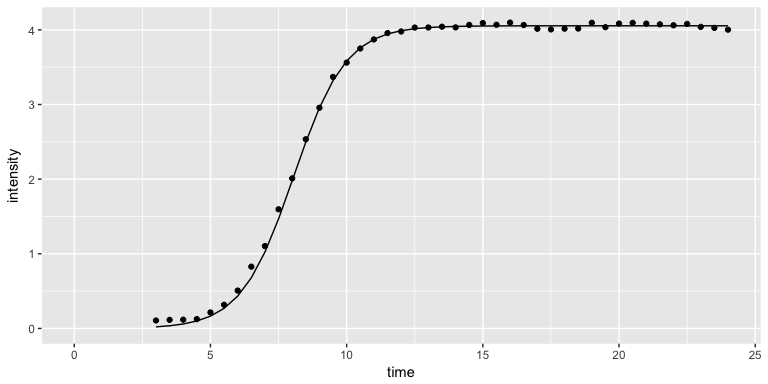

```r
intensityTheoretical=sicegar::sigmoidalFitFormula(time,
                                                  maximum=parameterVector$maximum_Estimate,
                                                  slopeParam=parameterVector$slopeParam_Estimate,
                                                  midPoint=parameterVector$midPoint_Estimate)
comparisonData=cbind(dataInput,intensityTheoretical)

ggplot2::ggplot(comparisonData)+
  ggplot2::geom_point(aes(x=time, y=intensity))+
  ggplot2::geom_line(aes(x=time,y=intensityTheoretical))+
  ggplot2::expand_limits(x = 0, y = 0)
```